# Project1_housing

Project 1: Housing dataset

The following project is guided by the question: Is it possible to accurately predict the sale prices of homes in Ames using different attributes of the homes in the dataset, especially those related to specific features in homes, neighborhoods, and the quality of homes?

Throughout this project I will conduct a series of a anlyses on the dataset regarding housing in the city of Ames, Iowa. The goal of this is to develop predictions on the sale price of a home given different attributes that are as accurate as possible.

This analysis could have practical applications since it shows what factors have more impact on housing costs compared to others.

```python
# Importing libraries
import pandas as pd
import numpy as np
import matplotlib.pyplot as plt
import seaborn as sns
```

```python
# Connect to Google Drive
from google.colab import drive
drive.mount('/content/drive')
print("Google Drive connected!")
```

```
Google Drive connected!
```

```python
# Import Data
data = pd.read_csv('/content/drive/My Drive/MATH_237/Datasets/ames-housing-train.csv')
```

Data Wrangling

```python
# First, check for missing values
missing_data = data.isnull().sum().sort_values(ascending=False)
missing_data[missing_data>0]
```

|  | 0 |
| --- | --- |
| PoolQC | 1453 |
| MiscFeature | 1406 |
| Alley | 1369 |
| Fence | 1179 |
| MasVnrType | 872 |
| FireplaceQu | 690 |
| LotFrontage | 259 |
| GarageQual | 81 |
| GarageFinish | 81 |
| GarageType | 81 |
| GarageYrBlt | 81 |
| GarageCond | 81 |
| BsmtFinType2 | 38 |
| BsmtExposure | 38 |
| BsmtCond | 37 |
| BsmtQual | 37 |
| BsmtFinType1 | 37 |
| MasVnrArea | 8 |
| Electrical | 1 |

**dtype:** int64

```python
# Next, handle the missing values
# For LotFrontage, I will replace the missing values with the median and for GarageYrBuilt I will replace NA values with 0
# PoolQC, Fence, and MiscFeature have lots of missing values simply due to the fact that there are many houses that just don't have these components.
# As such, I will simply drop these columns to make this analysis simpler.

data['LotFrontage'] = data['LotFrontage'].fillna(data['LotFrontage'].median())
data['GarageYrBlt'] = data['GarageYrBlt'].fillna(0)
data = data.drop(columns=['PoolQC', 'Fence', 'MiscFeature'])

#Verifying that the data was cleaned as intended.
data.info()
```

```
<class 'pandas.core.frame.DataFrame'>
RangeIndex: 1460 entries, 0 to 1459
Data columns (total 78 columns):
 #   Column         Non-Null Count  Dtype
---  ------         --------------  -----
 0   Id             1460 non-null   int64
 1   MSSubClass     1460 non-null   int64
 2   MSZoning       1460 non-null   object
 3   LotFrontage    1460 non-null   float64
 4   LotArea        1460 non-null   int64
 5   Street         1460 non-null   object
 6   Alley          91 non-null     object
 7   LotShape       1460 non-null   object
 8   LandContour    1460 non-null   object
 9   Utilities      1460 non-null   object
```

[output cut: 70 more lines]

Next, I will do some exploratory data analysis. A lot of this analysis will revolve around the SalePrice feature since it is the feature of interest. I will probably use multivariate regression to compare SalePrice to other features.

```python
#Summary statistics
data['SalePrice'].describe()
```

|  | SalePrice |
| --- | --- |
| count | 1460.000000 |
| mean | 180921.195890 |
| std | 79442.502883 |
| min | 34900.000000 |
| 25% | 129975.000000 |
| 50% | 163000.000000 |
| 75% | 214000.000000 |
| max | 755000.000000 |

**dtype:** float64

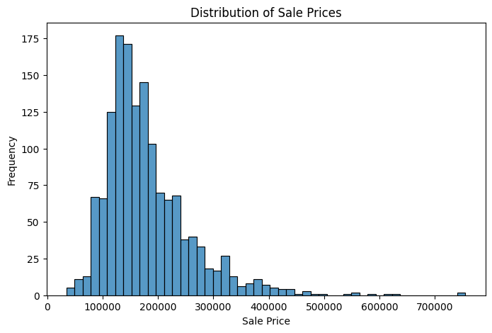

```python
#Histogram for SalePrice
plt.figure(figsize=(8, 5))
sns.histplot(data['SalePrice'])
plt.title("Distribution of Sale Prices")
plt.xlabel("Sale Price")
plt.ylabel("Frequency")
plt.show()
```

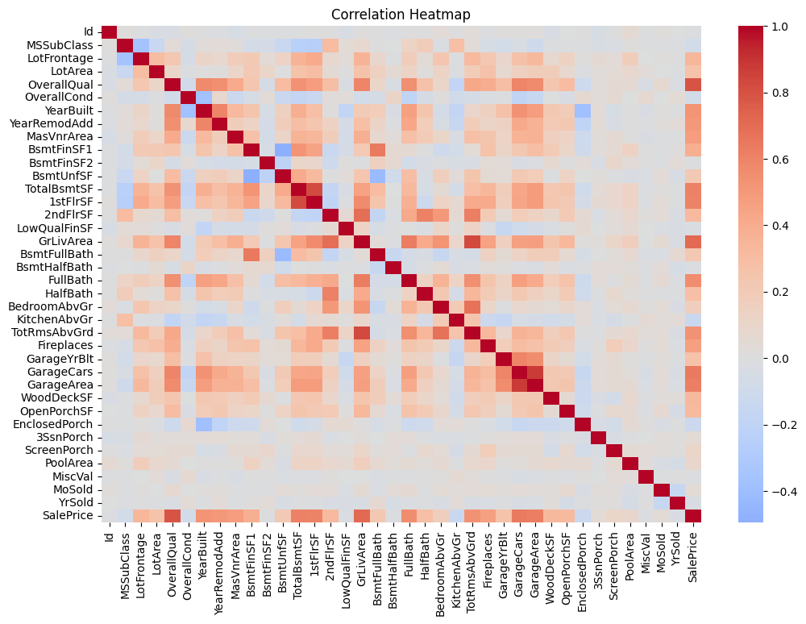

```python
#Heatmap to show the correlation between different features. This heatmap gives a good visual as to what features have the most bearing on SalePrice.

numeric_feats = data.select_dtypes(include=[np.number])
corr = numeric_feats.corr()
plt.figure(figsize=(12, 8))
sns.heatmap(corr, cmap='coolwarm', center=0)
plt.title("Correlation Heatmap")
plt.show()
```

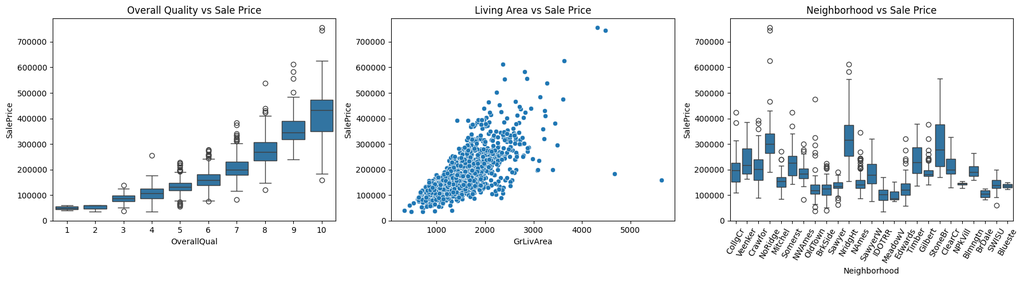

```python
#Relationship between key predictors and SalePrice, as seen in the heatmap above. Neighborhood is also included since it will be explored as well.

fig, axes = plt.subplots(1, 3, figsize=(18, 5))
sns.boxplot(x='OverallQual', y='SalePrice', data=data, ax=axes[0])
sns.scatterplot(x='GrLivArea', y='SalePrice', data=data, ax=axes[1])
sns.boxplot(x='Neighborhood', y='SalePrice', data=data, ax=axes[2])
axes[0].set_title("Overall Quality vs Sale Price")
axes[1].set_title("Living Area vs Sale Price")
axes[2].set_title("Neighborhood vs Sale Price")
axes[2].tick_params(axis='x', rotation=60)
plt.tight_layout()
plt.show()
```

```python
#Number of houses sold in each neighborhood (Feature engineering)
neighborhood_samples = data['Neighborhood'].value_counts()
print(neighborhood_samples)
```

```
Neighborhood
NAmes      225
CollgCr    150
OldTown    113
Edwards    100
Somerst     86
Gilbert     79
NridgHt     77
Sawyer      74
NWAmes      73
SawyerW     59
BrkSide     58
Crawfor     51
Mitchel     49
NoRidge     41
Timber      38
IDOTRR      37
ClearCr     28
SWISU       25
StoneBr     25
Blmngtn     17
MeadowV     17
BrDale      16
Veenker     11
NPkVill      9
Blueste      2
Name: count, dtype: int64
```

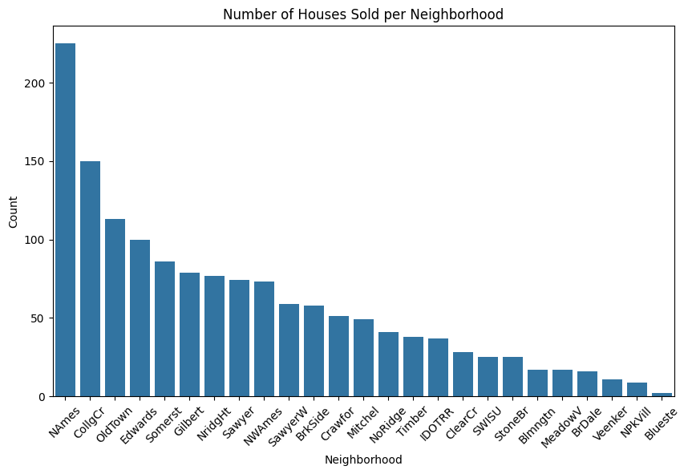

```python
#Visualization of the data
plt.figure(figsize=(10,6))
sns.barplot(x=neighborhood_samples.index, y=neighborhood_samples.values)
plt.xticks(rotation=45)
plt.title("Number of Houses Sold per Neighborhood")
plt.xlabel("Neighborhood")
plt.ylabel("Count")
plt.show()
```

```python
# This table shows the average sale prices of each neighborhood alongside the
# count of houses sold in each neighborhood.
neighborhood_summary = (data.groupby('Neighborhood')['SalePrice'].agg(['count', 'mean']).sort_values(by='mean', ascending=False).reset_index())

#Naming columns
neighborhood_summary.columns = ['Neighborhood', 'Number_of_Houses', 'Average_SalePrice']


print(neighborhood_summary)
```

```
   Neighborhood  Number_of_Houses  Average_SalePrice
0       NoRidge                41      335295.317073
1       NridgHt                77      316270.623377
2       StoneBr                25      310499.000000
3        Timber                38      242247.447368
4       Veenker                11      238772.727273
5       Somerst                86      225379.837209
6       ClearCr                28      212565.428571
7       Crawfor                51      210624.725490
8       CollgCr               150      197965.773333
9       Blmngtn                17      194870.882353
10      Gilbert                79      192854.506329
11       NWAmes                73      189050.068493
12      SawyerW                59      186555.796610
13      Mitchel                49      156270.122449
14        NAmes               225      145847.080000
15      NPkVill                 9      142694.444444
16        SWISU                25      142591.360000
17      Blueste                 2      137500.000000
18       Sawyer                74      136793.135135
19      OldTown               113      128225.300885
20      Edwards               100      128219.700000
21      BrkSide                58      124834.051724
22       BrDale                16      104493.750000
23       IDOTRR                37      100123.783784
24      MeadowV                17       98576.470588
```

```python
#Regression Model

#Needed sklearn imports
from sklearn.model_selection import train_test_split
from sklearn.linear_model import LinearRegression
from sklearn.metrics import mean_squared_error, r2_score

data['Number_of_Houses'] = data.groupby('Neighborhood')['Neighborhood'].transform('count') #Including the engineered feature.

features = [ 'OverallQual','GrLivArea', 'Number_of_Houses']
target = 'SalePrice'

#Split data
X = data[features]
y = data[target]

X_train, X_test, y_train, y_test = train_test_split(X, y, test_size=0.2, random_state=42)

#Training model
model = LinearRegression()
model.fit(X_train, y_train)

predictions = model.predict(X_test)

rmse = np.sqrt(mean_squared_error(y_test, predictions))
r2 = r2_score(y_test, predictions)

print(f"Root Mean Squared Error (RMSE): {rmse:.2f}")
print(f"R-squared: {r2:.3f}")

coefficients = pd.DataFrame({'Feature': features, 'Coefficient': model.coef_})

print("\nFeature Coefficients:")
print(coefficients)
```

```
Root Mean Squared Error (RMSE): 44145.78
R-squared: 0.746

Feature Coefficients:
            Feature   Coefficient
0       OverallQual  32347.913107
1         GrLivArea     52.810406
2  Number_of_Houses    -28.081325
```

Interpretation of the feature coefficients above:

- **OverallQual**: For a one point increase, the predicted sale price will increase by about $32,348.
- **GrLivArea**: For every additional square foot of living area above ground, the predicted sale price will increase by about $52.81.
- **Number_of_Houses**: For every additional house sold in a given neighborhood, the predicted sale price of the next house will decrease by about $28.08.

# Converting to HTML

```python
%%capture
# Convert this notebook to HTML
!jupyter nbconvert --to html "/content/drive/MyDrive/MATH_237/Project1_housing.ipynb"
```